# m2-u4-eda-case-study-georchat slides

[figure not shown]

**AI ENTERPRISE WORKFLOW CERTIFICATION**

### Case Study - Data visualization Solution

### Objectives

Recall that you are trying to identify the factors that contribute to the unique market situation in Singapore. Singapore has a higher rate of churn than the other markets and there is something in the data that, once uncovered, will allow you to make a hypothesis.

Your deliverable is a storyboard. The story should begin with descriptions of the data along with a summary of the business opportunity. The rest of the story details the process of your investigation and puts into context your findings. Finally, you should end with some discussion and suggestions about next steps in the process.

### Data Ingestion

- Let's consider a data ingestion script that readily accepts more data in batch form
- We will be using the AAVAIL datasets as a basis for this case study.
- Let's start by gathering data from the sources provided.

We will be working on necessary data given below:

- m2-u4-case-study.ipynb
- aavail-customers.db
- aavail-steams.csv

#### Exploratory Data Analysis

Sometimes it is known in advance which types of data integrity issues to expect, but other times it is during the Exploratory Data Analysis (EDA) process that these issues are identified.

After extracting data it is important to include checks for quality assurance even on the first pass through the AI workflow. Let's combine the data into a single structure and provide a couple checks for quality assurance.

**Implementation of checks for Quality Assurance**

- Remove any repeat customers based on customer_id
- Remove stream data that do not have an associated stream_id
- Check for missing values

**Combine the data into a single data structure**

The two most convenient structures for this task are Pandas dataframes and NumPy arrays. At a minimum ensure that your structure accommodates the following.

- A column for customer_id
- A column for country
- A column for age that is created from DOB
- A column customer_name that is created from first_name and last_name
- A column to indicate churn called is_subscriber
- A column that indicates subscriber_type that comes from invoice_item
- A column to indicate the total num_streams

|  | customer_id | country_name | age | customer_name | is_subscriber | subscriber_type | num_streams |
| --- | --- | --- | --- | --- | --- | --- | --- |
| 0 | 1 | united_states | 22 | Kasen Todd | 1 | aavail_premium | 23 |
| 1 | 2 | singapore | 31 | Ensley Garza | 0 | aavail_unlimited | 12 |
| 2 | 3 | united_states | 23 | Lillian Carey | 0 | aavail_premium | 22 |
| 3 | 4 | united_states | 21 | Beau Christensen | 1 | aavail_basic | 19 |
| 4 | 5 | singapore | 22 | Ernesto Gibson | 1 | aavail_premium | 23 |
| 5 | 6 | united_states | 23 | Deshawn Murray | 1 | aavail_premium | 20 |
| 6 | 7 | singapore | 50 | Daxton Tate | 0 | aavail_basic | 18 |
| 7 | 8 | united_states | 48 | Tenley Small | 1 | aavail_premium | 20 |
| 8 | 9 | united_states | 22 | Kyra Chase | 0 | aavail_premium | 24 |
| 9 | 10 | united_states | 27 | London Barber | 1 | aavail_basic | 20 |

Top ten rows of the cleaned dataset

### Investigative Visualization

Data visualization is the discipline of trying to understand data by placing it in a visual context so that patterns, trends and correlations that might not otherwise be detected can be exposed. The tables we just created above is difficult to navigate it can be useful to use a simple plot to summarize the data. It is possible that both a table and a plot might be needed to communicate the findings and one common practice is to include an appendix in the deliverable.

Another related practice when it comes to EDA is that the communication of your findings, usually via deliverable, is done in a clean and polished way. If using a notebook as a communication tool take the time to remove unnecessary code blocks and other elements as they can distract from the principal takeaways.

The goal here is to see what factors are influencing the Singapore situation and let's start by analyzing these factors.

**Analyze customer churn per market**

Let's create summary tables to get a better insight into the AAVAIL data. This will helpt ti understand the market size in US and Singapore and identify similarities/differences between the two markets. Remember the business objective is to identify the main factors in the market in Singapore.

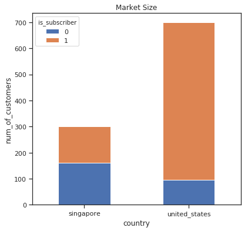

- The market size in Singapore is smaller than the US market (300 customers in Singapore, 700 in US)
- 54% of the customers in Singapore are non subscribers. In US this number corresponds to almost 14%)

**Analyze customer churn per market and subscription type**

We have an understanding of the market size in US and Singapore. We need to further investigate the data and get a deeper insight. I will analyze now the customers churn by market and subscription type.

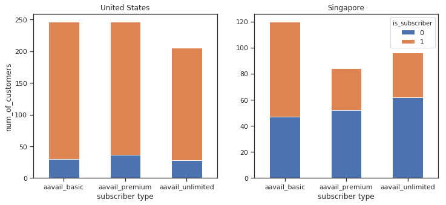

- For all products in US, the subscribers prevail the non-subscribers
- In Singapore, the non-subscribers are more for *unlimited* and *premium* products
- The highest number of non-subscribers in Singapore is of type *aavail-unlimited*, whereas the lowest is *aavail-basic*
- Subscribers in Singapore prefer the basic product to the unlimited and premium products (73 subscriptions for the basic, 66 subscriptions for the other two products together)

**Analyze customer churn in Singapore**

We have identified differences between the US and the Singapore market. We need now to focus more on the market in Singapore and get deeper insights. Let's further investigate the data and analyzed the numerical features in the dataset, **age** and **number of streams**

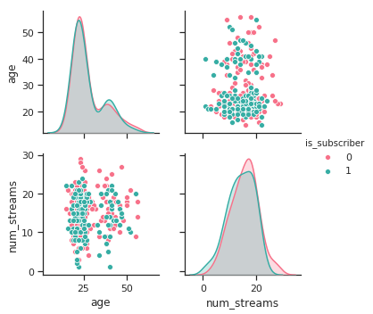

- The customers age distributions are almost identical for subscribers and non-subscribers
- The num_streams distribution has a bell-shape, the age distribution is skewed to the younger customers (shifted to the left)
- The two classes (0/1) are not linearly separable on the age-num_streams two dimensional space

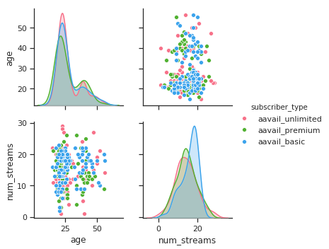

- The customers age distributions are almost identical for all subscriber types, where *unlimited* is narrower.
- The num_streams distribution for the basic product is slightly shifted to the right

**Analyze customer churn per age group in Singapore**

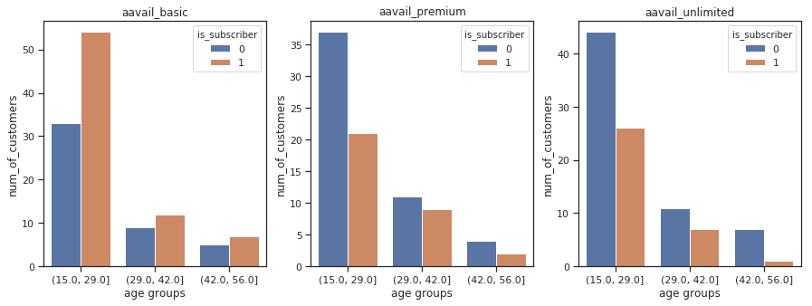

**Analyze customer churn per streams number in Singapore**

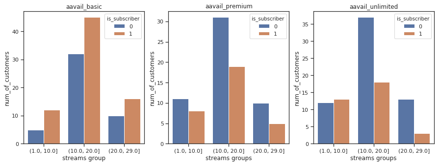

### Findings from the analysis of our Features

**As we undertsand that the goal of our data analysis was to find factors that are influencing the Singapore situation**

Here are some of the findings of the data analysis:

- There are more subscribers in the US than in Singapore
- In Singapore the basic product has the highest number of subscribers
- The highest churn rate in Singapore is observed in the unlimited product
- The main target group is young customers between 15 and 29 years old
- The average number of streams for all products for subscribers and non-subscribers is 15 streams

### Next Steps

From the findings abover we understand some of the important factors influencing our goal to be the subscriber_type, age and location but our findings does not provide any specific or deep insights on the factors that influence our goal.

Some of the next steps that can be performed are:

- Deep Dive Data analysis on each feature - We can use PCA (Principal Component Analysis) to explore the variations in variables.
- Hypothesis testing - We can hypothesize each feature and it's importance.
- We can also calculate multiple types of aggregations for any given feature for better data explorations.